# Task 3 Analysis: How Do Users Come Across Notes They Rate?

Using the enriched ratings dataset from `task3.ipynb` to answer three questions:

- Are the indicators well-calibrated?
- How common is each pathway system-wide?
- How do individual users mix pathways?

```python
import pandas as pd
import numpy as np
import matplotlib.pyplot as plt
import matplotlib.ticker as mtick
import warnings
warnings.filterwarnings('ignore')
from scipy.stats import spearmanr

plt.rcParams.update({'figure.dpi': 130, 'axes.spines.top': False, 'axes.spines.right': False})
BLUE, RED, GRAY, GREEN, ORANGE = '#3274A1', '#C9463D', '#888888', '#2ca02c', '#E07B39'
PATH_COLORS = {'Session': BLUE, 'Post-interest': GREEN, 'Notification': ORANGE, 'Swarm': RED}

ENRICHED = '../../data/ratings-enriched.parquet'
SESSION_GAP, SWARM_THRESH, POST_MIN = 5, 0.50, 2
```

```python
df = pd.read_parquet(ENRICHED)
print(f'Loaded: {df.shape[0]:,} rows x {df.shape[1]} cols')

INDICATORS = {
    'in_session':        'Session',
    'post_interest':     'Post-interest',
    'from_notification': 'Notification',
    'in_swarm':          'Swarm',
}
df.head(2)
```

```
Loaded: 6,499,635 rows x 13 cols
```

|  | noteId | ratedOnTweetId | raterParticipantId | noteAuthorParticipantId | postCreatedAt | noteCreatedAt | ratingCreatedAt | helpfulnessLevel | fromNotification | in_session | post_interest | from_notification | in_swarm |
| --- | --- | --- | --- | --- | --- | --- | --- | --- | --- | --- | --- | --- | --- |
| 0 | 2016534713742061788 | 2016246745739546987 | 00002C7FD6E0080A69D0AB879C3D9BB704BEFCC078AD40... | FD7979DE7F187DC14A4FDF8F5572424D060AA56E50AB30... | 2026-01-27 20:27:38.894 | 2026-01-28 15:31:55.816 | 2026-01-28 20:47:22.321 | HELPFUL | False | False | False | False | False |
| 1 | 2017641230612451495 | 2017578816177111423 | 00002C7FD6E0080A69D0AB879C3D9BB704BEFCC078AD40... | 2CE75633DDBFF074EE77E7DC582D7B557DC4D737E5FD81... | 2026-01-31 12:40:49.235 | 2026-01-31 16:48:49.996 | 2026-01-31 17:21:23.365 | HELPFUL | False | False | False | False | False |

## 1. Attribution Quality

```python
# Core proportions table
prop = pd.DataFrame({
    'Pathway':   list(INDICATORS.values()),
    'Ratings':   [df[c].sum() for c in INDICATORS],
    'Pct':       [100 * df[c].mean() for c in INDICATORS],
})
prop['Not attributed'] = len(df) - prop['Ratings']
print('=== Attribution proportions ===')
print(prop[['Pathway','Ratings','Pct']].to_string(index=False))
print(f'\nTotal ratings: {len(df):,}')

# Ratings with ZERO indicators
none_mask = ~df[list(INDICATORS)].any(axis=1)
print(f'\nRatings with NO indicator: {none_mask.sum():,}  ({100*none_mask.mean():.1f}%)')

# Ratings with 2+ indicators
multi_mask = df[list(INDICATORS)].sum(axis=1) >= 2
print(f'Ratings with 2+ indicators: {multi_mask.sum():,}  ({100*multi_mask.mean():.1f}%)')
```

```
=== Attribution proportions ===
      Pathway  Ratings       Pct
      Session  3837599 59.043300
Post-interest  3309659 50.920690
 Notification   128736  1.980665
        Swarm   179975  2.769002

Total ratings: 6,499,635

Ratings with NO indicator: 2,423,324  (37.3%)
Ratings with 2+ indicators: 3,297,912  (50.7%)
```

### Conflict checks

Looking for two problematic combinations: (1) ratings that are mid-session but also flagged as notification/swarm — these shouldn't happen often since notifications are entry points not mid-session triggers; (2) swarm ratings that heavily overlap with sessions, which would suggest swarms are just concentrated session activity.

```python
df = df.sort_values(['raterParticipantId', 'ratingCreatedAt'])
df['prev_gap_min'] = (
    df.groupby('raterParticipantId')['ratingCreatedAt']
    .diff().dt.total_seconds() / 60
)

interior = df['in_session'] & (df['prev_gap_min'] <= SESSION_GAP)
print(f'Interior-session ratings: {interior.sum():,}  ({100*interior.mean():.1f}%)')

c1_notif = (interior & df['from_notification']).sum()
c1_swarm = (interior & df['in_swarm']).sum()
print(f'Interior-session + notification: {c1_notif:,}  ({100*c1_notif/interior.sum():.2f}%)')
print(f'Interior-session + swarm:        {c1_swarm:,}  ({100*c1_swarm/interior.sum():.2f}%)')

swarm_mask = df['in_swarm']
print(f'\nSwarm + session:      {(swarm_mask & df["in_session"]).sum():,}  ({100*(swarm_mask & df["in_session"]).mean()/swarm_mask.mean():.1f}% of swarm)')
print(f'Swarm + notification: {(swarm_mask & df["from_notification"]).sum():,}  ({100*(swarm_mask & df["from_notification"]).mean()/swarm_mask.mean():.1f}% of swarm)')
```

```
Interior-session ratings: 2,588,816  (39.8%)
Interior-session + notification: 20,722  (0.80%)
Interior-session + swarm:        67,575  (2.61%)

Swarm + session:      97,919  (54.4% of swarm)
Swarm + notification: 2,292  (1.3% of swarm)
```

### Threshold robustness

```python
df['next_gap_min'] = (
    df.groupby('raterParticipantId')['ratingCreatedAt']
    .diff(-1).dt.total_seconds().abs() / 60
)

session_results = []
for t in [1, 2, 5, 10, 15]:
    flag = ((df['prev_gap_min'] <= t) | (df['next_gap_min'] <= t)).fillna(False)
    session_results.append({'threshold_min': t, 'pct_flagged': 100 * flag.mean()})

sess_df = pd.DataFrame(session_results)
print('Session threshold sweep:')
print(sess_df.to_string(index=False))
```

```
Session threshold sweep:
 threshold_min  pct_flagged
             1    53.141184
             2    55.889969
             5    59.043300
            10    61.436896
            15    62.829251
```

```python
df['rating_hour'] = df['ratingCreatedAt'].dt.floor('h')
note_total = df.groupby('noteId')['ratingCreatedAt'].count().rename('total')
note_max_hour = (
    df.groupby(['noteId', 'rating_hour'])['ratingCreatedAt'].count()
    .groupby(level='noteId').max().rename('peak')
)
note_frac = (note_max_hour / note_total).rename('peak_frac')

swarm_results = []
for t in [0.25, 0.33, 0.50, 0.67, 0.75]:
    swarm_notes = note_frac[note_frac >= t].index
    pct = 100 * df['noteId'].isin(swarm_notes).mean()
    swarm_results.append({'threshold_pct': int(t*100), 'pct_ratings': round(pct, 2), 'n_notes': len(swarm_notes)})

swarm_df2 = pd.DataFrame(swarm_results)
print('Swarm threshold sweep:')
print(swarm_df2.to_string(index=False))
```

```
Swarm threshold sweep:
 threshold_pct  pct_ratings  n_notes
            25        16.76    69242
            33         7.93    56710
            50         2.77    43564
            67         1.18    31228
            75         0.97    30840
```

```python
upc = df.groupby(['raterParticipantId', 'ratedOnTweetId'])['noteId'].nunique().reset_index(name='notes_on_post')

post_results = []
for t in [2, 3, 5, 10]:
    pairs = upc[upc['notes_on_post'] >= t][['raterParticipantId', 'ratedOnTweetId']].assign(flag=True)
    merged = df[['raterParticipantId', 'ratedOnTweetId']].merge(pairs, on=['raterParticipantId', 'ratedOnTweetId'], how='left')['flag'].fillna(False)
    post_results.append({'min_notes': t, 'pct_flagged': round(100 * merged.mean(), 2)})

post_df = pd.DataFrame(post_results)
print('Post-interest threshold sweep:')
print(post_df.to_string(index=False))
```

```
Post-interest threshold sweep:
 min_notes  pct_flagged
         2        50.92
         3        27.71
         5        10.21
        10         2.08
```

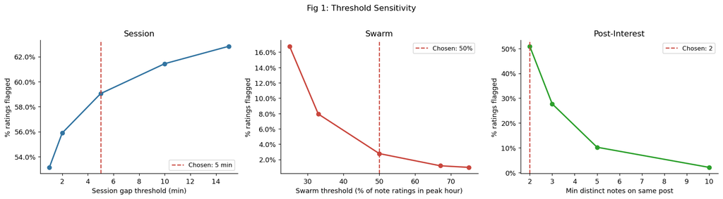

```python
fig, axes = plt.subplots(1, 3, figsize=(15, 4))

ax = axes[0]
ax.plot(sess_df['threshold_min'], sess_df['pct_flagged'], 'o-', color=BLUE, linewidth=2)
ax.axvline(SESSION_GAP, color=RED, linestyle='--', linewidth=1.5, label=f'Chosen: {SESSION_GAP} min')
ax.set_xlabel('Session gap threshold (min)')
ax.set_ylabel('% ratings flagged')
ax.set_title('Session')
ax.legend(fontsize=9)
ax.yaxis.set_major_formatter(mtick.PercentFormatter())

ax = axes[1]
ax.plot(swarm_df2['threshold_pct'], swarm_df2['pct_ratings'], 'o-', color=RED, linewidth=2)
ax.axvline(int(SWARM_THRESH*100), color=RED, linestyle='--', linewidth=1.5, label=f'Chosen: {int(SWARM_THRESH*100)}%')
ax.set_xlabel('Swarm threshold (% of note ratings in peak hour)')
ax.set_ylabel('% ratings flagged')
ax.set_title('Swarm')
ax.legend(fontsize=9)
ax.yaxis.set_major_formatter(mtick.PercentFormatter())

ax = axes[2]
ax.plot(post_df['min_notes'], post_df['pct_flagged'], 'o-', color=GREEN, linewidth=2)
ax.axvline(POST_MIN, color=RED, linestyle='--', linewidth=1.5, label=f'Chosen: {POST_MIN}')
ax.set_xlabel('Min distinct notes on same post')
ax.set_ylabel('% ratings flagged')
ax.set_title('Post-Interest')
ax.legend(fontsize=9)
ax.yaxis.set_major_formatter(mtick.PercentFormatter())

plt.suptitle('Fig 1: Threshold Sensitivity', y=1.02, fontsize=12)
plt.tight_layout()
plt.savefig('task3_threshold_sensitivity.png', bbox_inches='tight')
plt.show()
```

## 2. System-Wide Pathway Prevalence

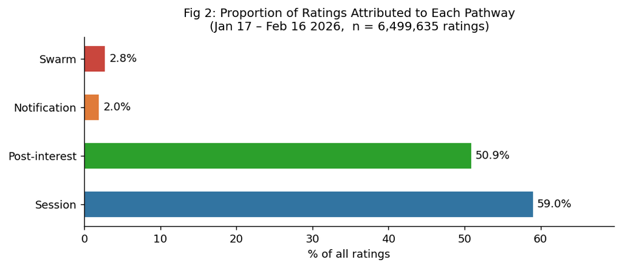

```python
labels = list(INDICATORS.values())
pcts   = [100 * df[c].mean() for c in INDICATORS]
colors = [PATH_COLORS[l] for l in labels]

fig, ax = plt.subplots(figsize=(8, 3.5))
bars = ax.barh(labels, pcts, color=colors, edgecolor='white', height=0.55)
for bar, pct in zip(bars, pcts):
    ax.text(pct + 0.5, bar.get_y() + bar.get_height() / 2,
            f'{pct:.1f}%', va='center', fontsize=10)
ax.set_xlabel('% of all ratings')
ax.set_xlim(0, max(pcts) * 1.18)
ax.set_title('Fig 2: Proportion of Ratings Attributed to Each Pathway\n'
             '(Jan 17 – Feb 16 2026,  n = 6,499,635 ratings)', fontsize=11)
plt.tight_layout()
plt.savefig('task3_overall_proportions.png', bbox_inches='tight')
plt.show()
```

### Stability over time

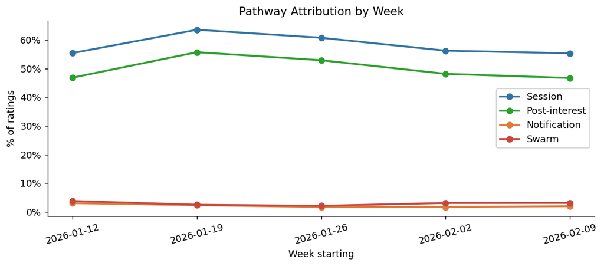

```
            Session  Post-interest  Notification  Swarm
2026-01-12     55.4           46.8           3.0    3.8
2026-01-19     63.5           55.7           2.3    2.5
2026-01-26     60.7           52.9           1.7    2.1
2026-02-02     56.2           48.1           1.7    3.1
2026-02-09     55.3           46.7           1.9    3.1
```

```python
df['week_start'] = df['ratingCreatedAt'].dt.to_period('W').dt.start_time

week_sizes = df.groupby('week_start').size()
full_weeks = week_sizes[week_sizes > 200_000].index
dfw = df[df['week_start'].isin(full_weeks)]

weekly = dfw.groupby('week_start')[list(INDICATORS)].mean().mul(100)
weekly.columns = list(INDICATORS.values())
weekly.index = [str(d.date()) for d in weekly.index]

fig, ax = plt.subplots(figsize=(9, 4))
for pathway in INDICATORS.values():
    ax.plot(weekly.index, weekly[pathway], marker='o', linewidth=2,
            label=pathway, color=PATH_COLORS[pathway])
ax.set_xlabel('Week starting')
ax.set_ylabel('% of ratings')
ax.yaxis.set_major_formatter(mtick.PercentFormatter())
ax.legend()
ax.set_title('Pathway Attribution by Week')
plt.xticks(rotation=15)
plt.tight_layout()
plt.savefig('task3_weekly_trend.png', bbox_inches='tight')
plt.show()

print(weekly.round(1).to_string())
```

### By helpfulness outcome

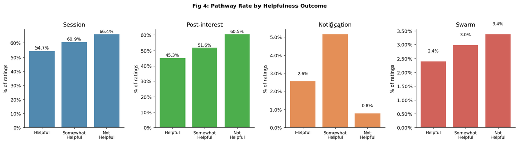

```
Pathway rates by helpfulness level (%):
                  Session  Post-interest  Notification  Swarm
helpfulnessLevel
HELPFUL              54.7           45.3           2.6    2.4
SOMEWHAT_HELPFUL     60.9           51.6           5.2    3.0
NOT_HELPFUL          66.4           60.5           0.8    3.4
```

```python
hl_order = ['HELPFUL', 'SOMEWHAT_HELPFUL', 'NOT_HELPFUL']

hl_rates = (
    df.groupby('helpfulnessLevel')[list(INDICATORS)]
    .mean()
    .mul(100)
    .loc[hl_order]
)
hl_rates.columns = list(INDICATORS.values())

fig, axes = plt.subplots(1, 4, figsize=(15, 4), sharey=False)
x = range(len(hl_order))
hl_labels = ['Helpful', 'Somewhat\nHelpful', 'Not\nHelpful']

for ax, pathway in zip(axes, INDICATORS.values()):
    vals = hl_rates[pathway].values
    bars = ax.bar(x, vals, color=PATH_COLORS[pathway], edgecolor='white', alpha=0.85)
    for bar, v in zip(bars, vals):
        ax.text(bar.get_x() + bar.get_width()/2, v + 0.3, f'{v:.1f}%',
                ha='center', va='bottom', fontsize=9)
    ax.set_xticks(list(x))
    ax.set_xticklabels(hl_labels, fontsize=9)
    ax.set_title(pathway)
    ax.set_ylabel('% of ratings')
    ax.yaxis.set_major_formatter(mtick.PercentFormatter())

plt.suptitle('Fig 4: Pathway Rate by Helpfulness Outcome', fontsize=11, y=1.02, fontweight='bold')
plt.tight_layout()
plt.savefig('task3_by_helpfulness.png', bbox_inches='tight')
plt.show()

print('\nPathway rates by helpfulness level (%):')
print(hl_rates.round(1).to_string())
```

## 3. Individual User Pathway Mix

```python
user_totals = df.groupby('raterParticipantId').size().rename('n_ratings')
user_path = df.groupby('raterParticipantId')[list(INDICATORS)].mean().mul(100)
user_path.columns = list(INDICATORS.values())
user_path = user_path.join(user_totals)

print(f'Users: {len(user_path):,}')
print(user_path[list(INDICATORS.values())].describe(percentiles=[.25,.5,.75,.9]).round(1).to_string())
```

```
Users: 484,059
        Session  Post-interest  Notification     Swarm
count  484059.0       484059.0      484059.0  484059.0
mean       30.8           27.4           3.6       3.4
std        35.2           33.5          15.2      13.0
min         0.0            0.0           0.0       0.0
25%         0.0            0.0           0.0       0.0
50%        11.8            0.0           0.0       0.0
75%        62.5           54.2           0.0       0.0
90%        85.0           80.0           2.6       7.1
max       100.0          100.0         100.0     100.0
```

### Dominant pathway per user

```python
user_active = user_path[user_path['n_ratings'] >= 10].copy()
path_cols = list(INDICATORS.values())

user_active['dominant'] = user_active[path_cols].idxmax(axis=1)
user_active['dominant_pct'] = user_active[path_cols].max(axis=1)

dom_counts = user_active['dominant'].value_counts()
print(dom_counts.to_string())
print()
print(dom_counts.div(len(user_active)).mul(100).round(1).rename('pct').to_string())
print('\nMedian dominant-pathway fraction:')
print(user_active.groupby('dominant')['dominant_pct'].median().round(1).to_string())
```

```
dominant
Session          119594
Post-interest      8174
Notification       1539
Swarm              1285

dominant
Session          91.6
Post-interest     6.3
Notification      1.2
Swarm             1.0

Median dominant-pathway fraction:
dominant
Notification     28.6
Post-interest    53.6
Session          57.1
Swarm             9.1
```

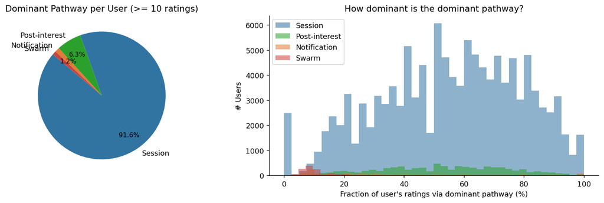

```python
fig, axes = plt.subplots(1, 2, figsize=(13, 4))

ax = axes[0]
vals = [dom_counts.get(p, 0) for p in path_cols]
wedges, texts, autotexts = ax.pie(
    vals, labels=path_cols, colors=[PATH_COLORS[p] for p in path_cols],
    autopct=lambda p: f'{p:.1f}%' if p > 1 else '', startangle=140, pctdistance=0.75
)
for t in autotexts: t.set_fontsize(9)
ax.set_title('Dominant Pathway per User (>= 10 ratings)')

ax = axes[1]
for p in path_cols:
    subset = user_active[user_active['dominant'] == p]['dominant_pct']
    ax.hist(subset, bins=40, alpha=0.55, label=p, color=PATH_COLORS[p], edgecolor='none')
ax.set_xlabel("Fraction of user's ratings via dominant pathway (%)")
ax.set_ylabel('# Users')
ax.set_title('How dominant is the dominant pathway?')
ax.legend()

plt.tight_layout()
plt.savefig('task3_dominant_pathway.png', bbox_inches='tight')
plt.show()
```

### How many pathways does a typical user use?

```python
MEANINGFUL_THRESH = 10.0
user_active['n_pathways_used'] = (user_active[path_cols] > MEANINGFUL_THRESH).sum(axis=1)

mix_dist = user_active['n_pathways_used'].value_counts().sort_index()
mix_pct  = mix_dist / len(user_active) * 100

print(f'Active users (>= 10 ratings): {len(user_active):,}')
for k, n in mix_dist.items():
    print(f'  {k} pathways (>{MEANINGFUL_THRESH}%): {n:,}  ({mix_pct[k]:.1f}%)')
```

```
Active users (>= 10 ratings): 130,592
  0 pathways (>10.0%): 4,631  (3.5%)
  1 pathways (>10.0%): 5,335  (4.1%)
  2 pathways (>10.0%): 109,002  (83.5%)
  3 pathways (>10.0%): 11,293  (8.6%)
  4 pathways (>10.0%): 331  (0.3%)
```

```python
# Stacked bar: average pathway composition, split by n_pathways_used
mix_avg = (
    user_active.groupby('n_pathways_used')[path_cols]
    .mean()
)
print('Average pathway composition by number of pathways used (%):')
print(mix_avg.round(1).to_string())
```

```
Average pathway composition by number of pathways used (%):
                 Session  Post-interest  Notification  Swarm
n_pathways_used
0                    1.5            1.1           0.8    2.2
1                   21.5            3.8           3.6    2.8
2                   57.2           51.2           1.0    1.9
3                   52.8           44.1          10.5   10.0
4                   53.2           39.9          23.5   16.7
```

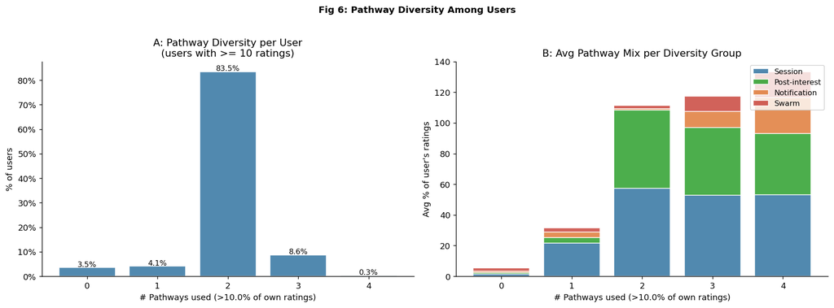

```python
fig, axes = plt.subplots(1, 2, figsize=(14, 5))

# Panel A: Bar of how many pathways users use
ax = axes[0]
ax.bar(mix_pct.index, mix_pct.values, color=BLUE, edgecolor='white', alpha=0.85)
for k, v in mix_pct.items():
    ax.text(k, v + 0.4, f'{v:.1f}%', ha='center', fontsize=9)
ax.set_xlabel(f'# Pathways used (>{MEANINGFUL_THRESH}% of own ratings)')
ax.set_ylabel('% of users')
ax.set_title(f'A: Pathway Diversity per User\n(users with >= 10 ratings)')
ax.yaxis.set_major_formatter(mtick.PercentFormatter())

# Panel B: Stacked bar of avg pathway mix by n_pathways_used group
ax = axes[1]
bottom = np.zeros(len(mix_avg))
for p in path_cols:
    vals = mix_avg[p].values
    ax.bar(mix_avg.index, vals, bottom=bottom,
           label=p, color=PATH_COLORS[p], edgecolor='white', alpha=0.85)
    bottom += vals
ax.set_xlabel(f'# Pathways used (>{MEANINGFUL_THRESH}% of own ratings)')
ax.set_ylabel('Avg % of user\'s ratings')
ax.set_title('B: Avg Pathway Mix per Diversity Group')
ax.legend(fontsize=9, loc='upper right')

plt.suptitle('Fig 6: Pathway Diversity Among Users', y=1.02, fontsize=11, fontweight='bold')
plt.tight_layout()
plt.savefig('task3_pathway_diversity.png', bbox_inches='tight')
plt.show()
```

### Pathway usage vs. rating volume

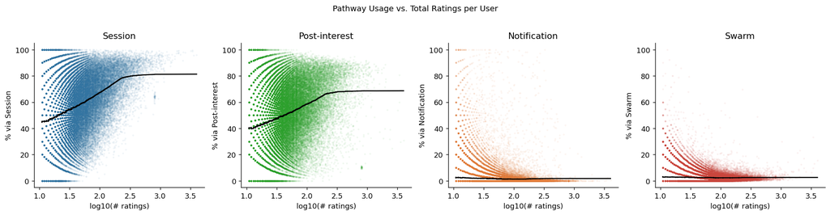

```python
fig, axes = plt.subplots(1, 4, figsize=(16, 4))

for ax, pathway in zip(axes, path_cols):
    ax.scatter(np.log10(user_active['n_ratings'] + 1), user_active[pathway],
               alpha=0.07, s=6, color=PATH_COLORS[pathway], linewidths=0)
    tmp = user_active[['n_ratings', pathway]].copy().sort_values('n_ratings')
    tmp['log_n'] = np.log10(tmp['n_ratings'] + 1)
    rolling = tmp.set_index('log_n')[pathway].rolling(5000, min_periods=100, center=True).mean()
    ax.plot(rolling.index, rolling.values, color='black', linewidth=1.5)
    ax.set_xlabel('log10(# ratings)')
    ax.set_ylabel(f'% via {pathway}')
    ax.set_title(pathway)

plt.suptitle('Pathway Usage vs. Total Ratings per User', fontsize=11, y=1.02)
plt.tight_layout()
plt.savefig('task3_volume_vs_pathway.png', bbox_inches='tight')
plt.show()
```

### Pathway mix vs. helpful-rating rate

```python
helpful_rate = (
    df.groupby('raterParticipantId')
    .apply(lambda g: (g['helpfulnessLevel'] == 'HELPFUL').mean() * 100)
    .rename('helpful_rate')
)
user_active = user_active.join(helpful_rate)

print('Spearman r: pathway fraction vs. helpful-rating rate')
for p in path_cols:
    r, pval = spearmanr(user_active[p], user_active['helpful_rate'])
    sig = '***' if pval < 0.001 else ('**' if pval < 0.01 else ('*' if pval < 0.05 else ''))
    print(f'  {p:<18s}  r={r:+.3f}  p={pval:.2e}  {sig}')
```

```
Spearman r: pathway fraction vs. helpful-rating rate
  Session             r=-0.288  p=0.00e+00  ***
  Post-interest       r=-0.354  p=0.00e+00  ***
  Notification        r=+0.074  p=1.03e-156  ***
  Swarm               r=-0.039  p=1.35e-44  ***
```

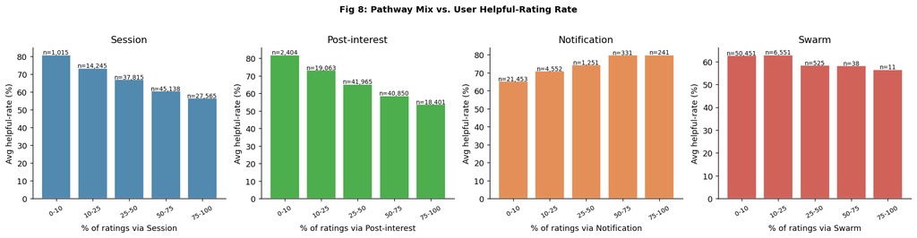

```python
fig, axes = plt.subplots(1, 4, figsize=(16, 4))

for ax, p in zip(axes, path_cols):
    # Bin users by pathway fraction
    bins = [0, 10, 25, 50, 75, 100]
    labels_b = ['0-10', '10-25', '25-50', '50-75', '75-100']
    user_active['bin'] = pd.cut(user_active[p], bins=bins, labels=labels_b, right=True)
    means = user_active.groupby('bin', observed=True)['helpful_rate'].mean()
    counts = user_active.groupby('bin', observed=True).size()
    ax.bar(range(len(means)), means.values,
           color=PATH_COLORS[p], edgecolor='white', alpha=0.85)
    for i, (v, c) in enumerate(zip(means.values, counts.values)):
        ax.text(i, v + 0.3, f'n={c:,}', ha='center', fontsize=7.5)
    ax.set_xticks(range(len(means)))
    ax.set_xticklabels(labels_b, rotation=30, fontsize=8)
    ax.set_xlabel(f'% of ratings via {p}')
    ax.set_ylabel('Avg helpful-rate (%)')
    ax.set_title(p)

plt.suptitle('Fig 8: Pathway Mix vs. User Helpful-Rating Rate',
             fontsize=11, y=1.02, fontweight='bold')
plt.tight_layout()
plt.savefig('task3_pathway_vs_helpful.png', bbox_inches='tight')
plt.show()
```

## Key Takeaways

**Session and Post-interest dominate** — 59% and 51% of ratings respectively — but they heavily overlap (~50% co-occurrence), so they're not really capturing separate things at the current threshold. The session indicator looks solid: moving the gap from 2 to 10 minutes barely changes the rate (56% → 61%), and mid-session ratings rarely conflict with notifications (0.8%) or swarms (2.6%). Post-interest is probably over-attributed though. Getting flagged on 51% of ratings just from having ≥2 notes on the same post seems too permissive — raising to ≥3 notes drops it to 28%, which feels more intentional.

The swarm indicator has an artifact issue: notes with only 1–2 ratings trivially qualify (100% peak-hour fraction), and 54% of swarm ratings also fall within sessions. That overlap suggests we're mostly picking up normal session activity on new notes rather than actual coordinated surges. Adding a minimum total-rating floor (e.g. ≥10) would help a lot.